# Example Report

Magdalena A. Tkacz

This document provides an example report structure based on the CRISP-DM methodology.

Students may use, modify, or extend the template as appropriate for their project.

The practical examples presented in this report are based on `penguin_mess`, a modified version of the `palmerpenguins` dataset created for educational purposes.

The dataset was intentionally altered to include selected data quality issues and should not be regarded as the original `palmerpenguins` dataset.

# Assessment Summary

Student name: Pen Guin

Intended grade:☐ 3.0 ☐ 3.5 ☑ 4.0 ☐ 4.5 ☐ 5.0

# Student Declaration

By submitting this report, I declare that:

- I understand all parts of the submitted work;
- I am able to explain and justify the analytical decisions presented in the report;
- the self-assessment table has been completed honestly;
- any use of AI tools was limited to assistance and does not substitute for my own understanding of the analysis;
- all external sources and tools used during the project have been properly acknowledged.

Submission of this report constitutes acceptance of this declaration.

# 0. Executive Summary

## Report Summary

This report presents a complete Data Mining workflow based on the CRISP-DM methodology. The analysis uses the penguin_mess dataset, a modified version of the Palmer Penguins dataset prepared for educational purposes.

The primary objective of the project is to predict penguin species using morphological measurements and selected categorical attributes.

The analysis follows the CRISP-DM (Cross-Industry Standard Process for Data Mining) methodology, progressing through business understanding, data understanding, data preparation, exploratory analysis, modeling, and evaluation.

## Success Criteria

The project will be considered successful if:

- data quality issues are identified and addressed;
- meaningful exploratory analysis is performed;
- at least two classification models are developed;
- model performance is evaluated and compared;
- conclusions are supported by analytical evidence.

# 1. Business Understanding

The objective of this project is to develop a predictive model capable of identifying penguin species based on available measurements and characteristics.

Although the dataset is educational in nature, the problem reflects a common Data Mining scenario in which historical observations are used to classify new cases. The project also aims to demonstrate the complete CRISP-DM process rather than maximize predictive performance.

The project aims to answer the following question:

> Can penguin species be accurately predicted using the available measurements and characteristics?

## Project Scope

The analysis includes: - data understanding and quality assessment; - data preparation and cleaning; - exploratory data analysis (EDA); - development of classification models; - model evaluation and comparison; - interpretation of results.

The project does not aim to build a production-ready system. Instead, it serves as a demonstration of the CRISP-DM process and fundamental Data Mining techniques.

## Problem Statement

Given a set of penguin observations containing morphological measurements and categorical characteristics, the objective is to develop a predictive model capable of correctly identifying the species of each penguin.

The project investigates which variables are most informative for species classification and evaluates whether reliable predictions can be obtained from the available data.

## Objective

The objective of this project is to investigate whether penguin species can be accurately predicted using available morphological measurements and categorical attributes.

To achieve this goal, the dataset will be explored, cleaned, and prepared for modeling. Multiple classification models will be developed and compared in order to identify the most suitable approach for this prediction task.

## Expected Outcome

The expected outcome of this project is the development of a classification model capable of predicting penguin species based on available measurements and categorical attributes. It is expected that the analysis will identify variables that are most informative for species classification and reveal patterns that distinguish different species.

Furthermore, the project is expected to demonstrate the impact of data preparation and feature selection on model performance, as well as provide a comparison of alternative modeling approaches.

# 2. Data Understanding

The purpose of this phase is to become familiar with the dataset and assess its suitability for the intended analysis. This includes examining the structure of the data, identifying variable types, evaluating data quality, and detecting potential issues that may affect subsequent stages of the project.

Particular attention is given to missing values, inconsistencies, unusual observations, and the distribution of individual variables. Understanding these characteristics is essential before proceeding to data preparation and model development.

## Dataset Description

The dataset was imported and inspected to understand its structure, variable types, and overall characteristics.

An initial review was performed to identify the number of observations, available variables, data types, and potential data quality issues that may require attention during the preparation phase.

```r
data <- read_csv(
  here("data", "penguins_mess.csv")
)
```

### Basic Dataset Information

```r
dim(data)
```

```
## [1] 520  10
```

So dataset has 520 observations and 10 variables.

Summary statistics

```r
summary(data)
```

```
##        id          species             island          bill_length_mm
##  Min.   :  1.0   Length:520         Length:520         Min.   :  0.50
##  1st Qu.:129.8   Class :character   Class :character   1st Qu.: 39.42
##  Median :258.5   Mode  :character   Mode  :character   Median : 43.85
##  Mean   :257.7                                         Mean   : 45.63
##  3rd Qu.:385.2                                         3rd Qu.: 48.20
##  Max.   :515.0                                         Max.   :999.00
##                                                        NA's   :26
##  bill_depth_mm   flipper_length_mm  body_mass_g        sex
##  Min.   :12.60   Min.   :   1.0    Min.   : -500   Length:520
##  1st Qu.:15.60   1st Qu.: 189.0    1st Qu.: 3563   Class :character
##  Median :17.60   Median : 196.0    Median : 4043   Mode  :character
##  Mean   :17.25   Mean   : 219.2    Mean   : 4332
##  3rd Qu.:18.80   3rd Qu.: 213.0    3rd Qu.: 4862
##  Max.   :21.70   Max.   :9999.0    Max.   :99000
##  NA's   :22      NA's   :20        NA's   :25
##       year         notes
##  Min.   :1999   Length:520
##  1st Qu.:2007   Class :character
##  Median :2008   Mode  :character
##  Mean   :2008
##  3rd Qu.:2009
##  Max.   :2099
##
```

## Dataset Structure

```r
glimpse(data)
```

```
## Rows: 520
## Columns: 10
## $ id                <dbl> 4, 322, 105, 309, 69, 101, 334, 406, 58, 49, 467, 45…
## $ species           <chr> "Gentoo", "Adelie", "Gentoo", "Adelie", "Adelie", "A…
## $ island            <chr> "Biscoe", "Torgersen", "Biscoe", "Torgersen", "Torge…
## $ bill_length_mm    <dbl> 46.8, 35.9, 48.6, 37.9, 39.3, 41.9, 46.1, 41.8, 35.9…
## $ bill_depth_mm     <dbl> 15.4, 19.0, 14.7, 19.8, 19.6, 18.9, 14.6, 17.9, 17.5…
## $ flipper_length_mm <dbl> 217, 201, 217, 198, NA, 194, 208, 192, 193, 206, 192…
## $ body_mass_g       <dbl> 4706, 2886, 4644, 3514, 3514, 3080, 4874, 4222, 4254…
## $ sex               <chr> NA, "male", "female", "male", "female", "male", "mal…
## $ year              <dbl> 2009, 2007, 2009, 2007, 2009, 2007, 2007, 2008, 2009…
## $ notes             <chr> NA, NA, NA, NA, NA, NA, NA, NA, NA, NA, NA, NA, NA, …
```

### Variable Description

The dataset contains a mixture of numerical and categorical variables. Understanding the role and data type of each variable is important for selecting appropriate preprocessing techniques, visualization methods, and modeling approaches. The following table summarizes the variables available in the dataset.

Summary of variables and missing values.

| Variable | Data_Type | Missing_Values |
| --- | --- | --- |
| id | numeric | 0 |
| species | character | 0 |
| island | character | 0 |
| bill_length_mm | numeric | 26 |
| bill_depth_mm | numeric | 22 |
| flipper_length_mm | numeric | 20 |
| body_mass_g | numeric | 25 |
| sex | character | 41 |
| year | numeric | 0 |
| notes | character | 484 |

## Data Quality Assessment

The dataset contains several missing values affecting both numerical and categorical variables. Missing values are particularly common in the `notes` attribute, where the majority of observations contain no information.

In addition, the dataset includes an identifier variable (`id`) which is not expected to contribute to predictive performance and may require removal before modeling.

The `notes` variable contains missing values in the majority of observations and provides limited analytical value. Therefore, it was excluded from further analysis.

### Missing Values

Missing values were examined to assess the completeness of the dataset and identify variables requiring additional preprocessing.

Missing values by variable.

|  | Variable | Missing_Values | Missing_Percent |
| --- | --- | --- | --- |
| notes | notes | 484 | 93.08 |
| sex | sex | 41 | 7.88 |
| bill_length_mm | bill_length_mm | 26 | 5.00 |
| body_mass_g | body_mass_g | 25 | 4.81 |
| bill_depth_mm | bill_depth_mm | 22 | 4.23 |
| flipper_length_mm | flipper_length_mm | 20 | 3.85 |
| id | id | 0 | 0.00 |
| species | species | 0 | 0.00 |
| island | island | 0 | 0.00 |
| year | year | 0 | 0.00 |

The dataset contains missing values in several variables. The highest proportion of missing data was observed in the `notes` attribute, while selected numerical and categorical variables also contain incomplete observations.

The impact of missing values will be assessed during the data preparation phase, where appropriate handling strategies will be applied.

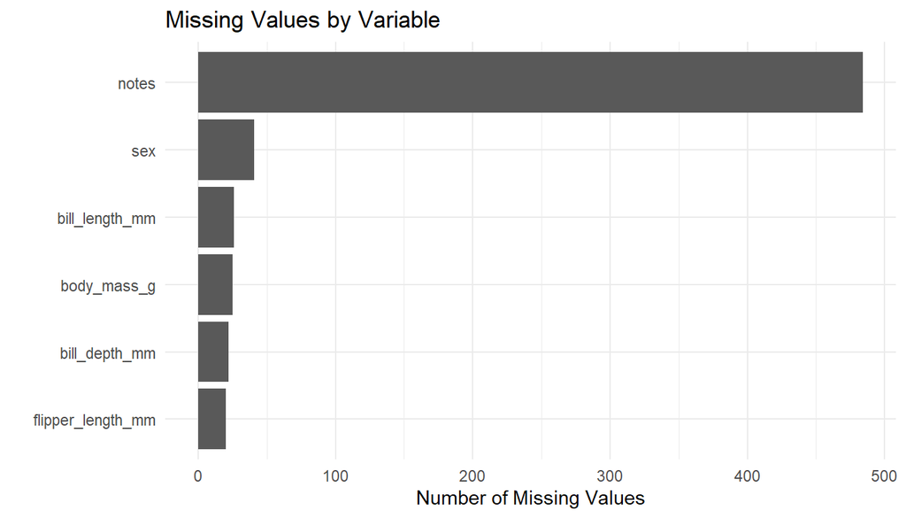

The analysis revealed missing values in both numerical and categorical variables. The largest number of missing observations was found in the `notes` attribute, whereas the remaining variables contain only a relatively small proportion of incomplete records.

The identified missing values will be addressed during the data preparation phase before model development.

### Duplicates

```r
sum(duplicated(data))
```

```
## [1] 5
```

So, in more details:

```r
data_no_id <- dplyr::select(data, -id)

sum(duplicated(data_no_id))
```

```
## [1] 19
```

Several data quality issues were identified during the initial assessment. Missing values are present in both numerical and categorical variables, with the highest proportion observed in the `notes` attribute.

In addition, a small number of duplicate observations were detected. These records will be reviewed during the data preparation phase to determine whether they should be retained or removed prior to model development.

### Outliers

Potential outliers were investigated using graphical methods and summary statistics. The objective was to identify observations that may disproportionately influence subsequent analyses and predictive models.

### Outliers

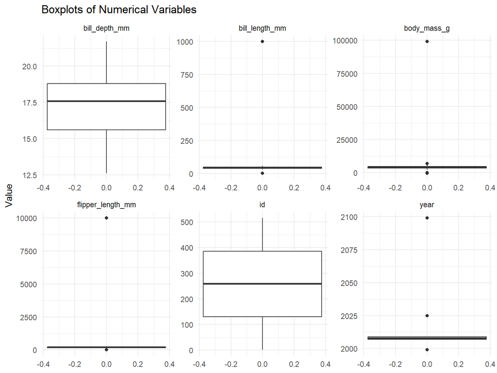

Several observations appear outside the whiskers of the boxplots. These values were retained at this stage of the analysis and will be further evaluated during data preparation.

## Initial Exploratory Analysis

An initial exploratory analysis was conducted to examine the distributions of individual variables and identify potential relationships between them. The analysis focuses on understanding the overall characteristics of the dataset and highlighting patterns that may be relevant for subsequent modeling tasks.

### Distribution of Numerical Variables

Histograms were generated for all numerical variables to examine their distributions, identify potential skewness, detect unusual observations, and assess overall data quality. This step provides an initial understanding of the range and shape of each variable before data cleaning and modelling.

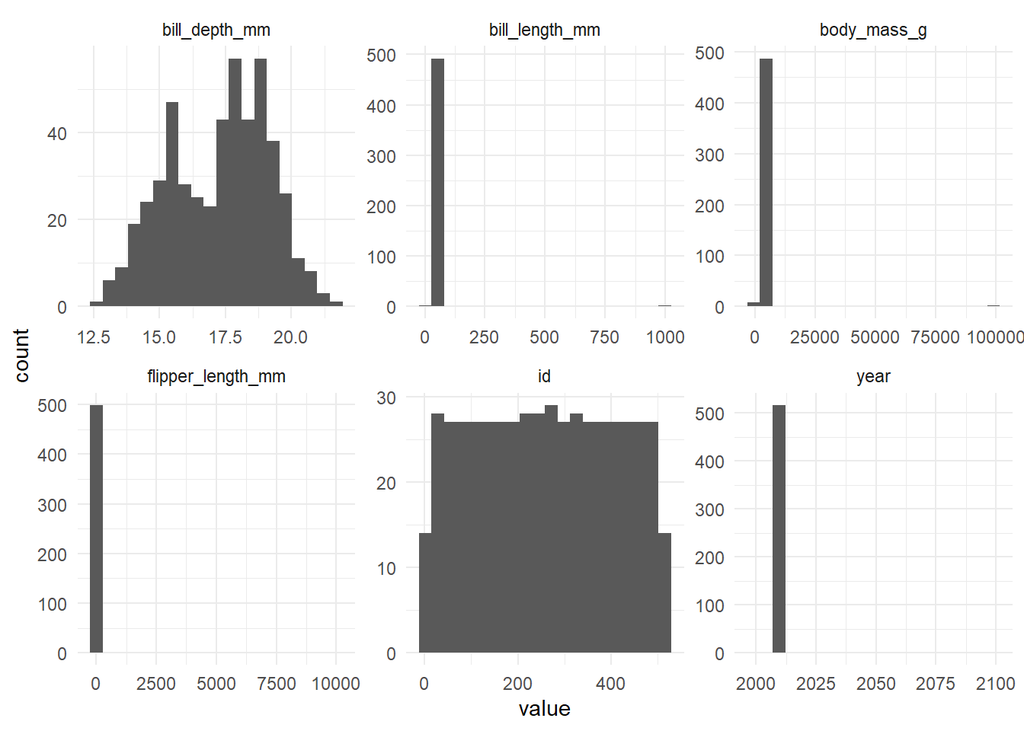

```r
data |>
  select(where(is.numeric)) |>
  pivot_longer(everything()) |>
  ggplot(aes(value)) +
  geom_histogram(bins = 20) +
  facet_wrap(~name, scales = "free")+
  theme_minimal()
```

The distributions of numerical variables exhibit several irregularities, including missing values and extreme observations. These characteristics may affect subsequent analyses and limit the interpretability of visualizations and predictive models. The observed patterns indicate that data preparation will be required before proceeding to model development.

### Distribution of Categorical Variables

Distribution of Categorical Variables The distribution of categorical variables was examined to understand the composition of the dataset and identify potential imbalances between categories. Bar charts were used to visualize the frequency of observations within each category.

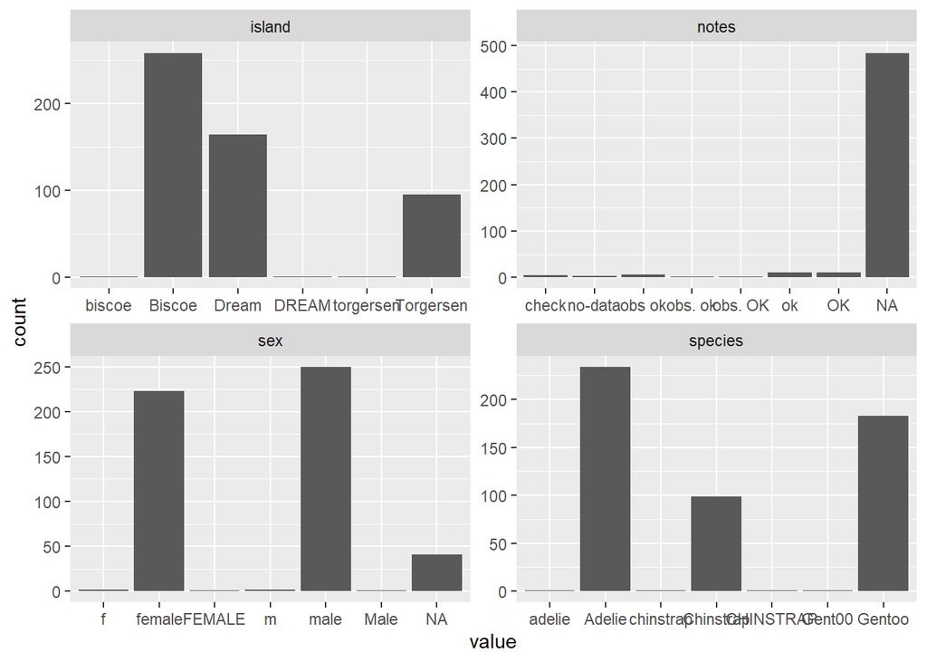

```r
data |>
  select(where(is.character)) |>
  pivot_longer(everything()) |>
  ggplot(aes(value)) +
  geom_bar() +
  facet_wrap(~name, scales = "free")
```

The examined categorical variables show varying frequencies across categories. These distributions contribute to a better understanding of the dataset and may be relevant during model development and evaluation.

### Relationships and Correlation Between Variables

Relationships between numerical variables were explored using a scatterplot and scatterplot matrix. This visualization allows pairwise comparison of a certain or all numerical attributes and helps identify potential correlations, clusters, trends, and unusual observations that may influence subsequent modelling steps.

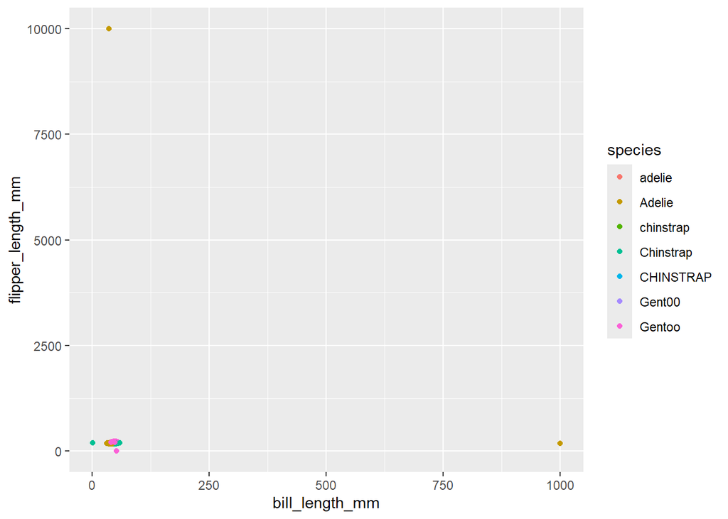

```r
ggplot(
  data,
  aes(
    bill_length_mm,
    flipper_length_mm,
    color = species
  )
) +
  geom_point()
```

The initial scatterplots were strongly influenced by extreme observations, making it difficult to visually assess relationships between variables. This suggests the presence of potential outliers that may require further investigation before meaningful interpretation can be performed.

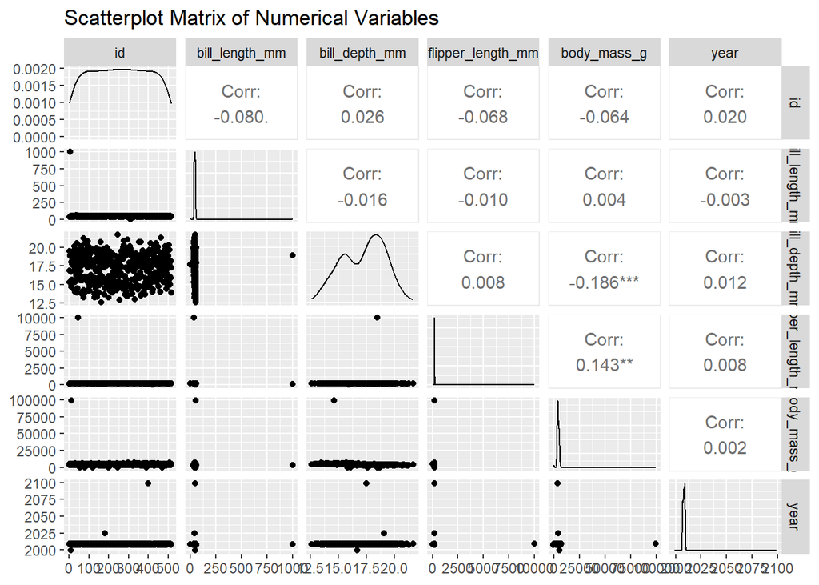

```r
library(GGally)

data |>
  select(where(is.numeric)) |>
  GGally::ggpairs(
    progress = FALSE,
    title = "Scatterplot Matrix of Numerical Variables"
  )
```

The visualization suggests that some numerical variables may be related. A more detailed investigation is required to determine whether these relationships are meaningful and relevant for predictive modelling.

The scatterplot matrix serves as an initial assessment of relationships between numerical variables. Visual inspection suggests that some variables may be correlated, although the strength and significance of these relationships cannot be reliably determined from the plots alone. Therefore, a dedicated correlation analysis is recommended to support feature selection and improve understanding of the dataset structure.

### Correlation Analysis

Correlation analysis was performed to quantify relationships between numerical variables. Understanding these relationships can support feature selection, help identify redundant information, and provide additional insight into the structure of the dataset.

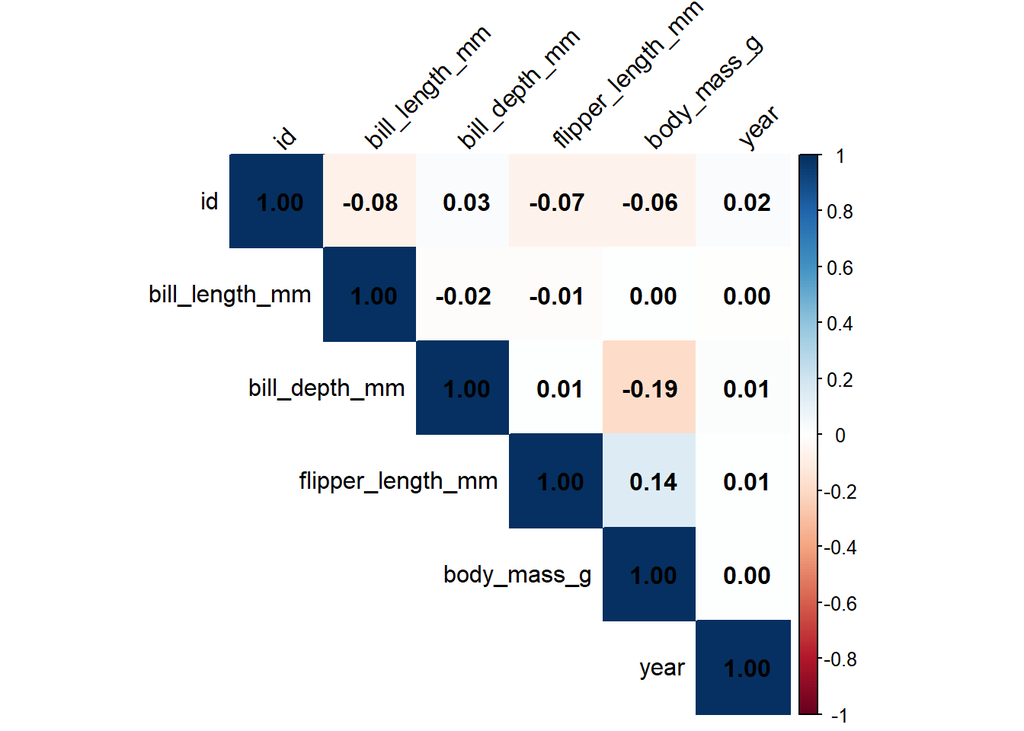

```r
library(corrplot)

cor_matrix <- data |>
  select(where(is.numeric)) |>
  cor(use = "pairwise.complete.obs")

corrplot(
  cor_matrix,
  method = "color",
  type = "upper",
  addCoef.col = "black",
  tl.col = "black",
  tl.srt = 45
)
```

The results indicate varying levels of correlation among the numerical variables. While some relationships appear stronger than others, the practical significance of these associations should be evaluated within the context of the modelling task. Correlation analysis serves as a useful exploratory tool but should not be used as the sole criterion for feature selection.

The correlation matrix provides a quantitative summary of linear relationships between numerical variables. Some variables exhibit stronger associations than others, suggesting that they may contain related information. Correlation analysis can help identify potentially redundant features and support feature selection during model development. However, correlation measures only linear relationships and should always be interpreted alongside exploratory visualisations and domain knowledge.

ℹ️️ **Correlation does not imply dependence**

Correlation measures only linear relationships between variables. A low correlation coefficient does not necessarily indicate the absence of a relationship.

Variables may exhibit non-linear dependencies that are not captured by correlation analysis. A classic example is the *Anscombe Quartet*, where several datasets share nearly identical summary statistics and correlation coefficients while displaying very different patterns when visualized.

For this reason, correlation analysis should always be complemented by exploratory visualisations and domain knowledge.

## Initial Observations

The dataset contains both numerical and categorical variables. Initial inspection suggests that some data cleaning will be necessary due to missing values and potential inconsistencies. Further exploratory analysis is required to better understand the structure and quality of the data.

# 3. Data Preparation

The exploratory analysis revealed several data quality issues that may affect the performance of predictive models. Therefore, a data cleaning process was performed to improve consistency, reduce noise, and prepare the dataset for further analysis and modelling.

## Missing Values

Missing values were identified in several variables. The notes column contained mostly missing observations and limited analytical value; therefore, it was removed from further analysis. Remaining missing values will be handled using appropriate preprocessing techniques during model development.

Removing `notes`:

```r
data <- data |>
  select(-notes)
```

Drop na in `species`:

```r
data <- data |>
  drop_na(species)
```

## Duplicates

Duplicate observations were identified and removed to prevent potential bias during model training and evaluation.

```r
data <- data |>
  distinct()
```

## Data Cleaning

### Outliers

```r
summary(data)
```

```
##        id          species             island          bill_length_mm
##  Min.   :  1.0   Length:515         Length:515         Min.   :  0.50
##  1st Qu.:129.5   Class :character   Class :character   1st Qu.: 39.40
##  Median :258.0   Mode  :character   Mode  :character   Median : 43.80
##  Mean   :258.0                                         Mean   : 45.62
##  3rd Qu.:386.5                                         3rd Qu.: 48.20
##  Max.   :515.0                                         Max.   :999.00
##                                                        NA's   :25
##  bill_depth_mm   flipper_length_mm  body_mass_g        sex
##  Min.   :12.60   Min.   :   1.0    Min.   : -500   Length:515
##  1st Qu.:15.60   1st Qu.: 189.0    1st Qu.: 3547   Class :character
##  Median :17.60   Median : 196.0    Median : 4041   Mode  :character
##  Mean   :17.25   Mean   : 219.3    Mean   : 4328
##  3rd Qu.:18.80   3rd Qu.: 213.0    3rd Qu.: 4852
##  Max.   :21.70   Max.   :9999.0    Max.   :99000
##  NA's   :21      NA's   :20        NA's   :25
##       year
##  Min.   :1999
##  1st Qu.:2007
##  Median :2008
##  Mean   :2008
##  3rd Qu.:2009
##  Max.   :2099
##
```

```r
data <- data |>
  filter(
    bill_length_mm < 100,
    flipper_length_mm < 400,
    body_mass_g < 10000,
    year < 2100
  )
```

## Transformations

### Standardizing Categorical Variables

```r
data <- data |>
  mutate(
    species = str_to_title(species),
    island = str_to_title(island),
    sex = str_to_lower(sex)
  )
```

And

```r
data <- data |>
  mutate(
    species = recode(
      species,
      "Gent00" = "Gentoo"
    ),
    sex = recode(
      sex,
      "m" = "male",
      "f" = "female"
    )
  )
```

Several categorical variables contained inconsistent labels resulting from differences in spelling, capitalisation, and data entry errors. Categories were standardised to ensure consistent representation across the dataset.

## Feature Selection / Engineering

Several modifications were applied during the data preparation stage.

The `notes` variable was removed because it contained a large proportion of missing values and provided limited analytical value. Duplicate records were removed to improve data consistency.

No new variables were created at this stage. Feature engineering will be limited to preprocessing steps required for model development, such as encoding categorical variables and handling remaining missing values.

Potential additional feature engineering techniques, such as creating derived variables or applying transformations, may be explored depending on the modelling approach and project objectives.

## Check

```r
glimpse(data)
```

```
## Rows: 443
## Columns: 9
## $ id                <dbl> 4, 322, 105, 309, 101, 334, 406, 58, 49, 467, 453, 4…
## $ species           <chr> "Gentoo", "Adelie", "Gentoo", "Adelie", "Adelie", "G…
## $ island            <chr> "Biscoe", "Torgersen", "Biscoe", "Torgersen", "Dream…
## $ bill_length_mm    <dbl> 46.8, 35.9, 48.6, 37.9, 41.9, 46.1, 41.8, 35.9, 44.3…
## $ bill_depth_mm     <dbl> 15.4, 19.0, 14.7, 19.8, 18.9, 14.6, 17.9, 17.5, 16.2…
## $ flipper_length_mm <dbl> 217, 201, 217, 198, 194, 208, 192, 193, 206, 192, 17…
## $ body_mass_g       <dbl> 4706, 2886, 4644, 3514, 3080, 4874, 4222, 4254, 4764…
## $ sex               <chr> NA, "male", "female", "male", "male", "male", "male"…
## $ year              <dbl> 2009, 2007, 2009, 2007, 2007, 2007, 2008, 2009, 2009…
```

```r
summary(data)
```

```
##        id          species             island          bill_length_mm
##  Min.   :  2.0   Length:443         Length:443         Min.   :31.20
##  1st Qu.:132.5   Class :character   Class :character   1st Qu.:39.50
##  Median :258.0   Mode  :character   Mode  :character   Median :43.60
##  Mean   :259.5                                         Mean   :43.69
##  3rd Qu.:386.5                                         3rd Qu.:48.10
##  Max.   :514.0                                         Max.   :58.30
##
##  bill_depth_mm   flipper_length_mm  body_mass_g       sex
##  Min.   :12.60   Min.   :  1.0     Min.   :-500   Length:443
##  1st Qu.:15.70   1st Qu.:189.0     1st Qu.:3563   Class :character
##  Median :17.60   Median :196.0     Median :4042   Mode  :character
##  Mean   :17.25   Mean   :199.6     Mean   :4130
##  3rd Qu.:18.70   3rd Qu.:213.0     3rd Qu.:4822
##  Max.   :21.70   Max.   :232.0     Max.   :6843
##  NA's   :20
##       year
##  Min.   :2007
##  1st Qu.:2007
##  Median :2008
##  Mean   :2008
##  3rd Qu.:2009
##  Max.   :2099
##
```

Category labels were standardized; however, some missing values remained in the sex variable. These observations were retained at this stage and will be handled during the modelling phase using an appropriate preprocessing strategy.

### Missing Values

Missing values were examined to assess the completeness of the dataset and identify variables requiring additional preprocessing.

Missing values by variable.

|  | Variable | Missing_Values | Missing_Percent |
| --- | --- | --- | --- |
| sex | sex | 36 | 8.13 |
| bill_depth_mm | bill_depth_mm | 20 | 4.51 |
| id | id | 0 | 0.00 |
| species | species | 0 | 0.00 |
| island | island | 0 | 0.00 |
| bill_length_mm | bill_length_mm | 0 | 0.00 |
| flipper_length_mm | flipper_length_mm | 0 | 0.00 |
| body_mass_g | body_mass_g | 0 | 0.00 |
| year | year | 0 | 0.00 |

The dataset still contains missing values in two variables. The impact of missing values will be assessed during the data preparation before modeling phase, where appropriate handling strategies will be applied.

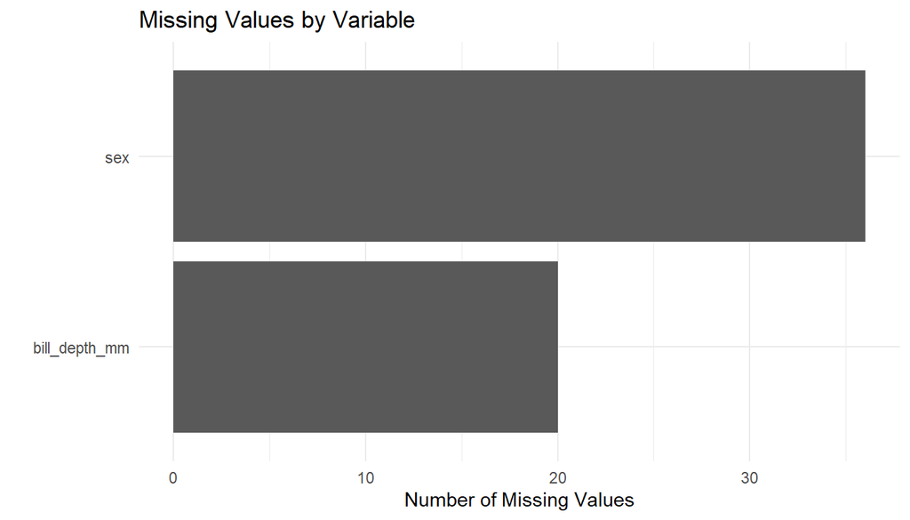

### Duplicates

```r
sum(duplicated(data))
```

```
## [1] 0
```

### Outliers

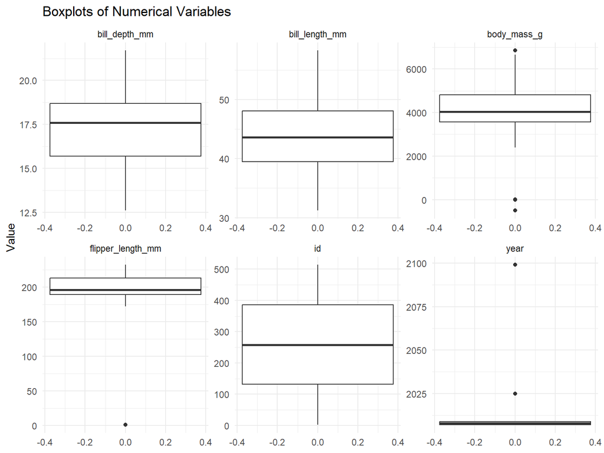

# 4. Exploratory Data Analysis (EDA)

## Distribution Analysis

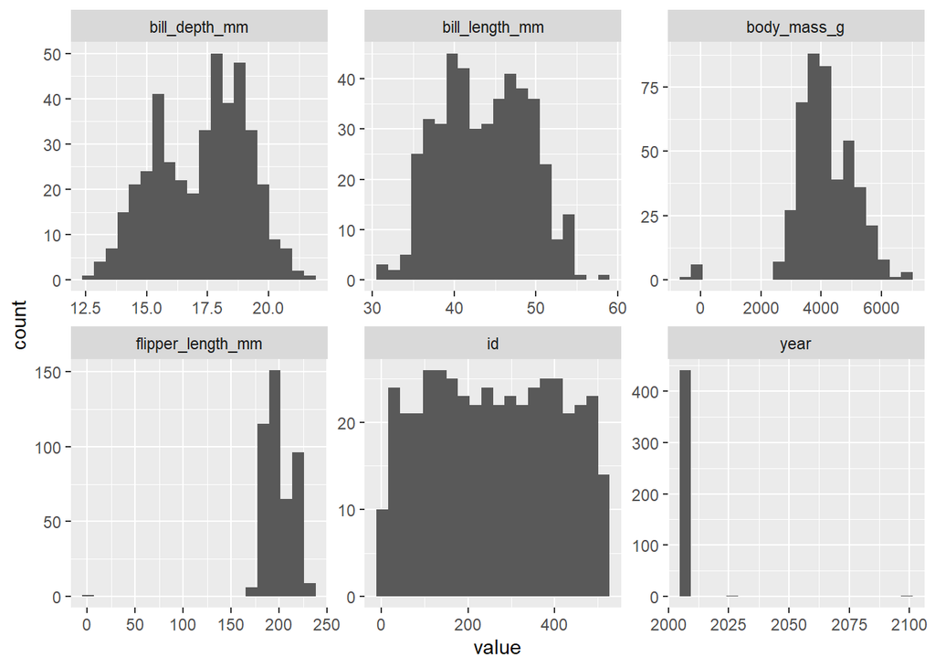

```r
data |>
  select(where(is.numeric)) |>
  pivot_longer(everything()) |>
  ggplot(aes(value)) +
  geom_histogram(bins = 20) +
  facet_wrap(~name, scales = "free")
```

### Interpretation

> The distributions provide an overview of the numerical variables and their ranges. Several variables exhibit unusual observations that may require further investigation. Understanding these distributions is important for selecting appropriate preprocessing and modelling techniques.

## Relationship Analysis

**Introduction**

> Relationships between numerical variables were explored using a scatterplot matrix. This visualization provides an overview of pairwise interactions and may reveal patterns worth investigating in later stages of the analysis.

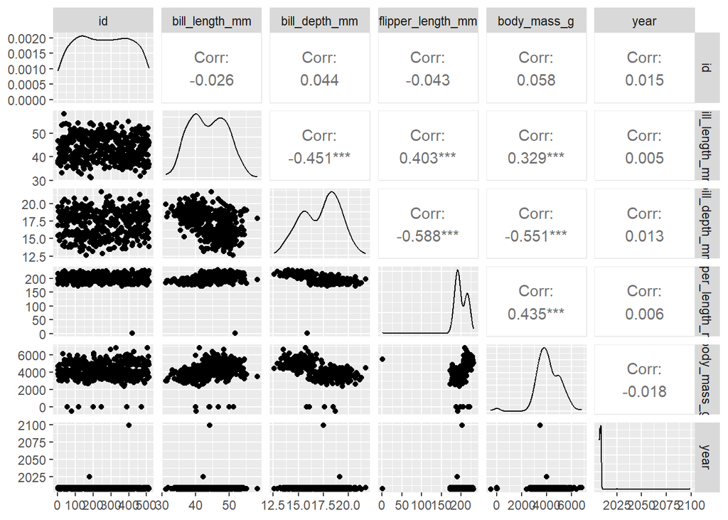

```r
library(GGally)

data |>
  select(where(is.numeric)) |>
  ggpairs(progress = FALSE)
```

### Interpretation

> The scatterplot matrix provides an initial overview of potential relationships among variables. Several patterns can be observed and may warrant further investigation during subsequent exploratory analysis and feature selection stages.